# RDA Exam

### Overview

We will be using the three datasets:

- [securities.csv](https://graderdata.s3.amazonaws.com/securities.txt)
- [fundamentals.csv](https://graderdata.s3.amazonaws.com/fundamentals.txt)
- [split adjusted price.csv](https://graderdata.s3.amazonaws.com/prices-split-adjusted.txt)

They were adapted from the webpage [New York Stock Exchange](https://www.kaggle.com/dgawlik/nyse), where the original raw data can be found.

#### Prob 1. Loading data

The csv file of split_adjusted_price.csv is saved in the url:

`url_adjusted = 'https://graderdata.s3.amazonaws.com/prices-split-adjusted.csv'`

Load the data into a dataframe, make sure that the `date` column is of a proper type.

**Hint**: The function `as.Date` might come in handy.

#### Prob 2. Missing values

The dataset `securities` is loaded for you.

```r
securities = read.csv('https://graderdata.s3.amazonaws.com/securities.csv', na.strings = "")
```

How many missing values are there in the column `Date.first.added`?

```r
securities %>% select(Date.first.added) %>% is.na() %>% sum()
```

```
## [1] 198
```

#### Prob 3. Join

The dataset `fundamentals` is loaded for you. Inner join `fundamentals` and `securities` on the ticker symbols. Save the answer into a variable, you will need it for the latter problems.

```r
fundamentals = read.csv('https://graderdata.s3.amazonaws.com/fundamentals.csv', na.strings = "", row.names=1)
```

```r
A = inner_join(fundamentals, securities, by=c("Ticker.Symbol"="Ticker.symbol"))
```

#### Prob 4. ggplot2

From the merged data frame from Prob 3., visualize the relation between `Earnings.Before.Interest.and.Tax` and `Total.Equity`.

[figure not shown]

```r
library(ggplot2)
```

#### Prob 5. ggplot2 (continue)

From the merged data frame from Prob 3., compare the `Accounts.Payable` for different `GICS.Sector`.

**Hint**: You **DO NOT** need to customize the plot for this exam. In real work, you might want to:

- Rotate the x-axis label to avoid overlapping by `+ theme(axis.text.x = element_text(angle = 90, hjust = 1))`
- Zoom in to neglect outliers by `+ ylim(NA, 5e10)`

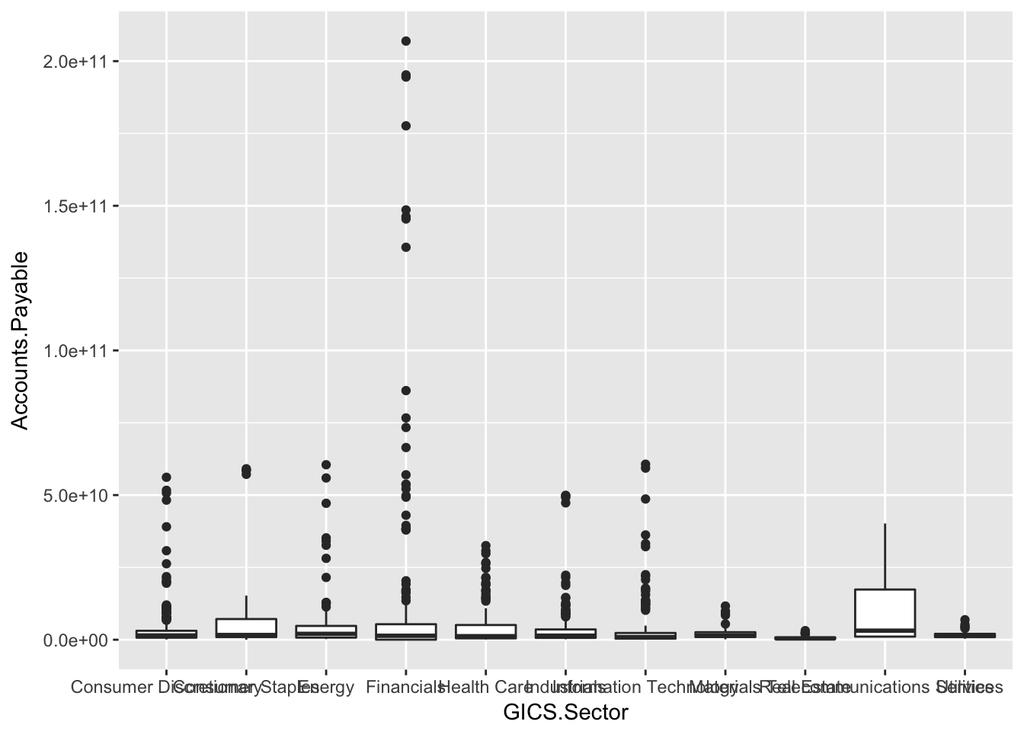

#### Prob 6. dplyr: Grouping and aggregating

From the merged data frame from Prob 3., find the `GICS.Sector` with the highest average `After.Tax.ROE`.

```r
library(dplyr)
```

[output not shown]